# Report - Final Assessment

Author

Flurina Jenal

Published

April 24, 2026

This Quarto report was created in the Public Health Science Course “Projects in R”.

## Download and initial data inspection

```r
covid_region_age <- read_csv(here("data", "raw", "COVID19Cases_geoRegion_AKL10_w.csv"))
str(covid_region_age)
unique(covid_region_age$geoRegion)
unique(covid_region_age$altersklasse_covid19)
```

### Selecting preferred dataset (arrange, mutate, filter and select)

After inspecting a publicly available dataset, the data is rearranged and filtered to only contain necessary information for further analysis. The dataset should include COVID entries in Switzerland, the age groups, the year and week numbers (timepoints of measurements).

```r
## Swiss covid entries from 2020-2023 ----
covid_ch <- covid_region_age %>%
  select(ageClass = altersklasse_covid19, geoRegion, entries, year = datum_dboardformated, pop) %>%
  filter(geoRegion == "CH") %>%
  filter(ageClass != "Unbekannt") %>%
  mutate(week = as.numeric(substr(year, 6, 7))) %>%
  filter(week != 53) %>%
  mutate(year = as.factor(substr(year, 1, 4))) %>%
  mutate(popPrct = (as.numeric((100/pop)*entries))) %>%
  mutate(across(c(geoRegion, ageClass), factor)) %>%
  arrange(year, week, ageClass)

levels(covid_ch$geoRegion)
levels(covid_ch$ageClass)
levels(covid_ch$year)
unique(covid_ch$week)
str(covid_ch)
```

Table 1 below shows all COVID entries from 2020 to 2023.

```r
## Table for Swiss covid entries from 2020-2023 ----
covid_ch |>
  select(year, entries) |>
  tbl_summary(by = year) |>
  add_overall()
```

Table 1: Summary of COVID entries from 2020 to 2023 in Switzerland.

| **Characteristic** | **Overall** N = 1,494<sup>1</sup> | **2020** N = 396<sup>1</sup> | **2021** N = 468<sup>1</sup> | **2022** N = 468<sup>1</sup> | **2023** N = 162<sup>1</sup> |
| --- | --- | --- | --- | --- | --- |
| entries | 932 (177, 2,702) | 172 (29, 931) | 1,137 (385, 2,093) | 2,724 (1,426, 5,755) | 122 (58, 198) |

<sup>1</sup> Median (Q1, Q3)

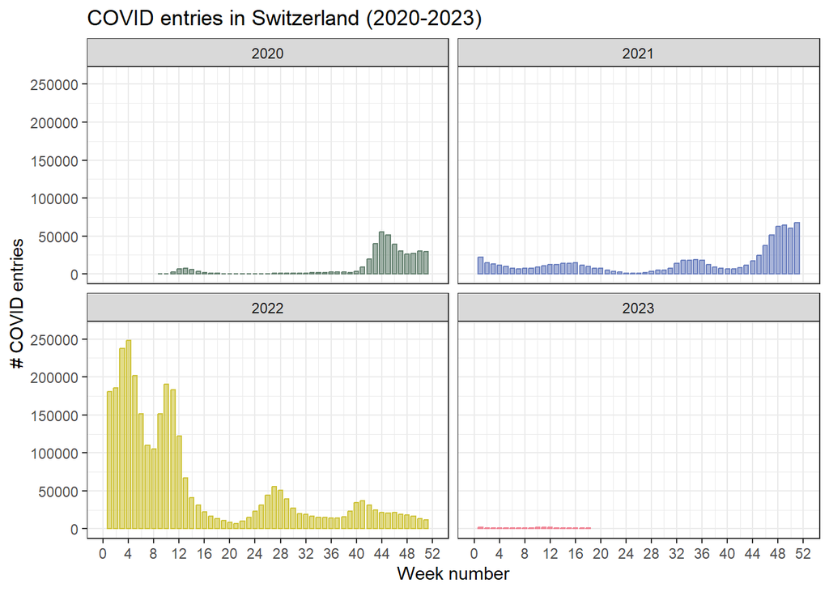

Figure 1

```r
## Plot for Swiss covid entries from 2020-2023 ----
# when were the most entries reported
covid_weekly <- covid_ch %>%
  group_by(year, week) %>%
  summarise(entries = sum(entries), .groups = "drop")

ggplot(covid_weekly, aes(x = week, y = entries)) +
  geom_col(mapping = aes(fill = year, colour = year),
           alpha = 0.6, linetype = "solid", linewidth = 0.5, width = 0.7, show.legend = FALSE) +
  scale_fill_manual(name = "year",
                    breaks = c("2020", "2021", "2022", "2023"),
                    labels = c("2020", "2021", "2022", "2023"),
                    values = c(unibeGreenS()[2], unibeIceS()[2], unibeMustardS()[2], unibePastelS()[2])) +
  scale_colour_manual(name = "year",
                      breaks = c("2020", "2021", "2022", "2023"),
                      labels = c("2020", "2021", "2022", "2023"),
                      values = c(unibeGreenS()[2], unibeIceS()[2], unibeMustardS()[2], unibePastelS()[2])) +
  scale_x_continuous(
    breaks = seq(0, 52, by = 4),        # major ticks: 1, 9, 17, ...
    minor_breaks = seq(0, 52, by = 2),  # minor grid: every 4 weeks
    limits = c(0, 52)) +
  scale_y_continuous(breaks = seq(from = 0, to = 260000, by = 50000),
                     limits = c(0, 260000)) +
  ggtitle(label="COVID entries in Switzerland (2020-2023)") +
  xlab(label = "Week number") +
  ylab(label = "# COVID entries") +
  labs(colour = "Year", fill = "Year") +
  theme_bw() +
  #theme(legend.position = "bottom") +
  facet_wrap(.~year)
```

## Data visualization

To better recognize patterns in COVID entries in Switzerland, data was further subset to only contain data from 2022.

#### Data inspection for subset “2022”

```r
### Subset data further for year == 2022 ----
covid_2022 <- covid_ch %>%
  filter(year == "2022")
str(covid_2022)
```

```
tibble [468 × 7] (S3: tbl_df/tbl/data.frame)
 $ ageClass : Factor w/ 9 levels "0 - 9","10 - 19",..: 1 2 3 4 5 6 7 8 9 1 ...
 $ geoRegion: Factor w/ 1 level "CH": 1 1 1 1 1 1 1 1 1 1 ...
 $ entries  : num [1:468] 9540 27152 46114 34447 27026 ...
 $ year     : Factor w/ 4 levels "2020","2021",..: 3 3 3 3 3 3 3 3 3 3 ...
 $ pop      : num [1:468] 883904 858994 1027732 1254957 1205539 ...
 $ week     : num [1:468] 1 1 1 1 1 1 1 1 1 2 ...
 $ popPrct  : num [1:468] 1.08 3.16 4.49 2.74 2.24 ...
```

#### Visual data inspection for subset “2022”

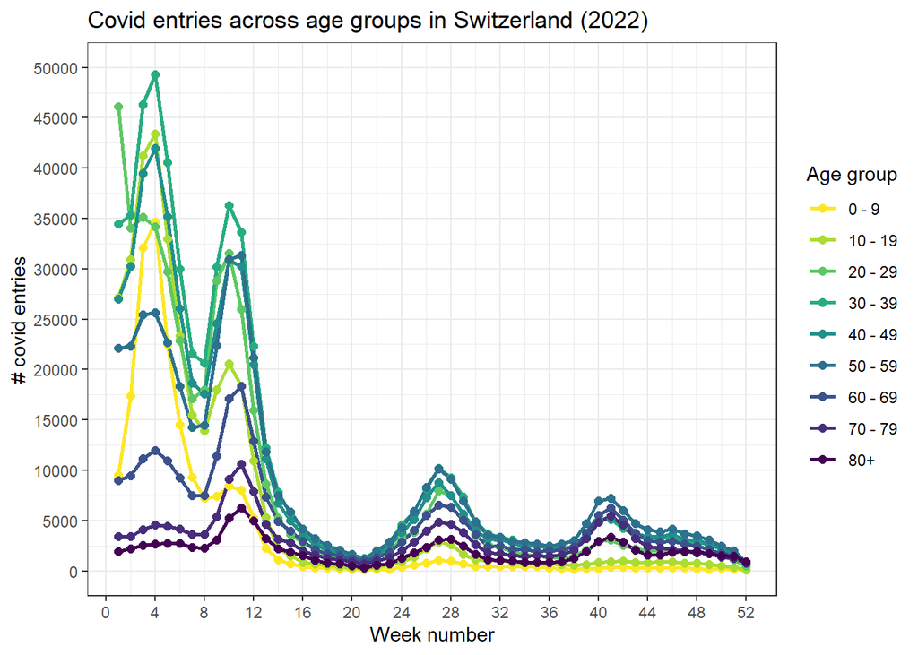

Figure 2: Number of COVID entries in Switzerland reported for each week during 2022 and accross age groups in the Swiss population.

```r
### Compare covid cases in 2022 across different age groups ----
ggplot(covid_2022, aes(x = week, y = entries)) +
  geom_line(mapping = aes(colour = ageClass), linetype = "solid", linewidth = 1.0) +
  #scale_color_viridis_d(direction = -1) +
  #scale_color_brewer(palette = "YlGnBu") +
  geom_point(mapping = aes(fill = ageClass, color = ageClass), shape = 21, size = 1.9) +
  scale_fill_viridis_d(direction = -1) +
  scale_color_viridis_d(direction = -1) +
  scale_x_continuous(
    breaks = seq(0, 52, by = 4),        # major ticks: 1, 9, 17, ...
    minor_breaks = seq(0, 52, by = 2),  # minor grid: every 4 weeks
    limits = c(1, 52)) +
  scale_y_continuous(breaks = seq(from = 0, to = 50000, by = 5000),
                     limits = c(0, 50000)) +
  ggtitle(label="Covid entries across age groups in Switzerland (2022)") +
  xlab(label = "Week number") +
  ylab(label = "# covid entries") +
  labs(color = "Age group", fill = "Age group") +
  theme_bw() +
  theme(legend.position = "right")
```

**Note for final assessment**

Since I’m a clinical data manager and therefore cannot share any specific work related data, I was working on the COVID datasets provided in the course. Thank you for considering this :)